# Colombia Health Loss

Yuhaniz Aly

# Columbia Health Loss

## Deaths

One metric of disease burden is the number of *deaths*. Below is a barchart of the top 10 diseases that cause the most health loss in Colombia:

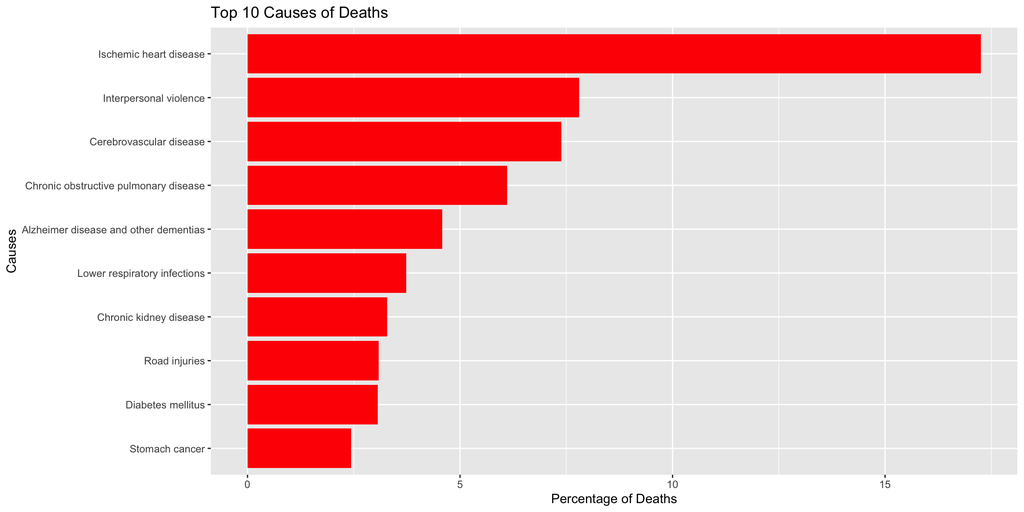

## YLLs

Another metric of disease burden is *Years of Life Lost (YLLs)*. This measures the years of potential life lost due to premature deaths. Below is a bar chart of the top 10 diseases as measured by YLLs.

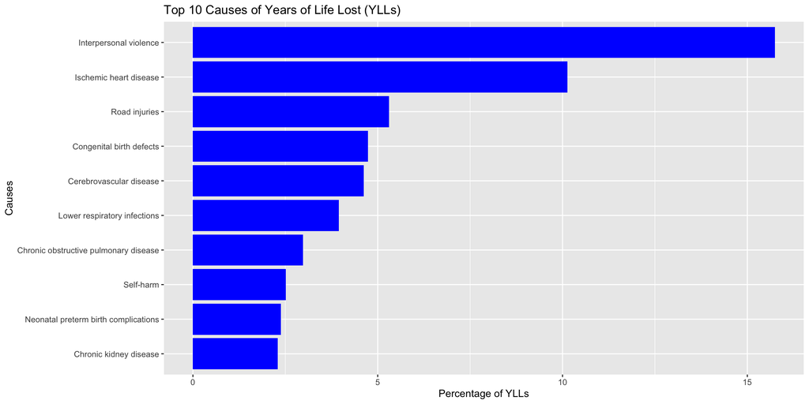

## YLDs

Another metric of disease burden is *Years of Lived with Disability (YLDs)*. This measures the years of potential life lost due to living with a disability. Below is a bar chart of the top 10 diseases as measured by YLDs.

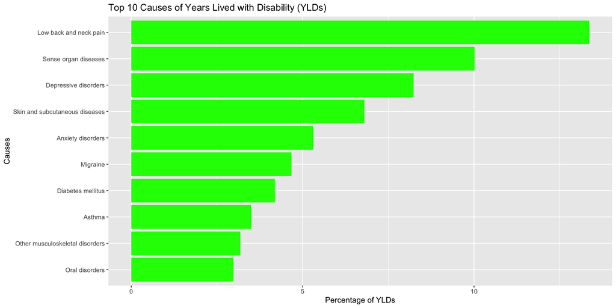

## DALYs

Lastly, another metric of disease burden is *Disability Adjusted Life Years (DALYs)*. This measures the overall disease burden, expressed the years of potential life lost due to ill-health, disability, or premature death. DALYs combines mortality and morbidity into one metric. Below is a bar chart of the top 10 diseases as measured by DALYs.

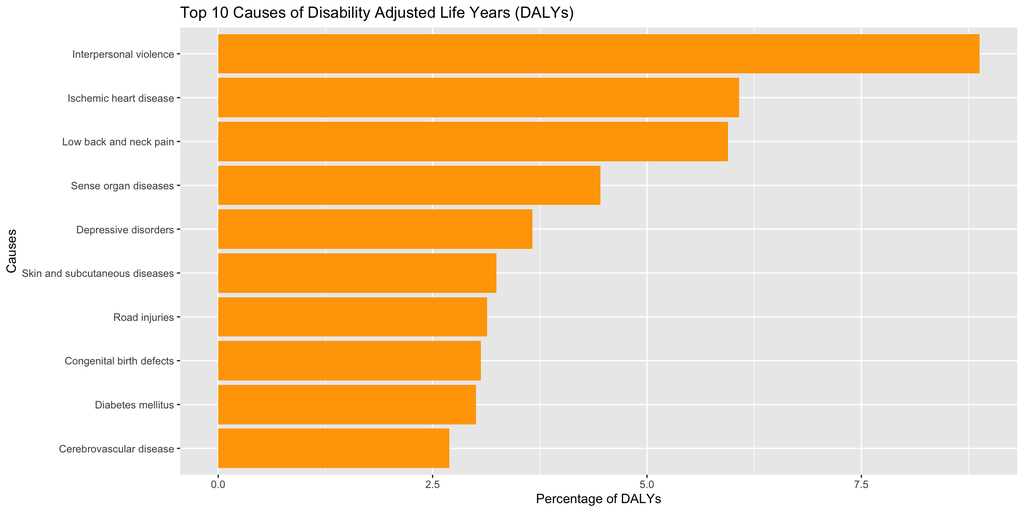

## Comparison of Asthma

Below is a barchart of different health metrics comparing asthma.

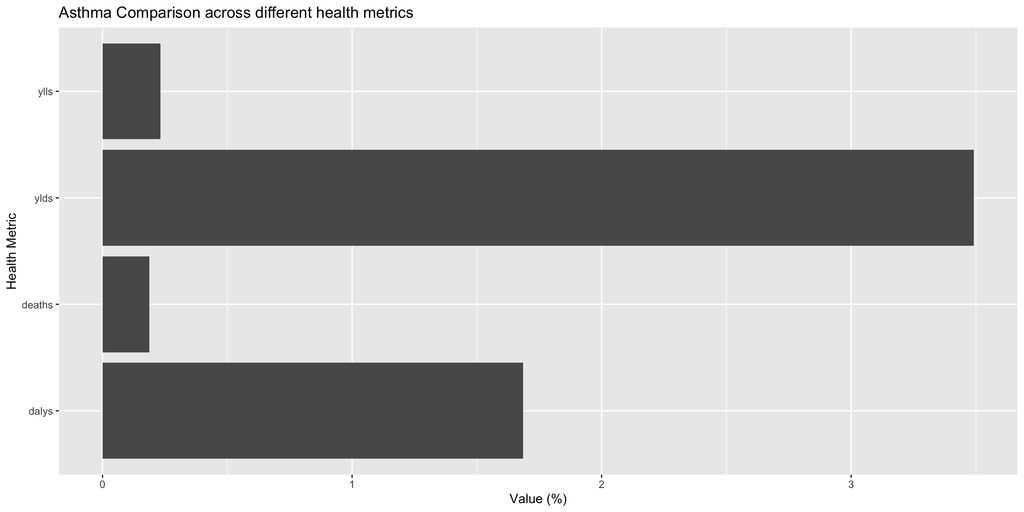

Based on the barchart, asthma has the most ylds and the least deaths. This means asthma is not a deadly health condition as not many people die from this cause. This is also shown for the ylls comparison because not many lifetime years are lost from asthma. In contrast, a higher percentage of people end up living with asthma, which explains the large percentage of ylds. Lastly, the DALYs tells us that the overall burden for asthma is about 1.7%.